# K-means clustering analysis

Hua Zou

zouhua1@outlook.com

Created: 2021-01-20; updated: 2021-01-30

### What is K-means clustering

> K-means clustering is a technique in which we place each observation in a dataset into one of K clusters.

> The end goal is to have K clusters in which the observations within each cluster are quite similar to each other while the observation in different clusters are quite different from each other.

> In practice, we use the following steps to perform K-means clustering:
> 1. **Choose a value for K**
> 2. **Randomly assign each observation to an initial cluster, from 1 to K**
> 3. **Perform the following procedure until the cluster assignments stop changing**
> - For each of the K clusters, compute the cluster centroid. This is simply the vector of the p feature means for the observations in the kth cluster.
> - Assign each observation to the cluster whose centroid is closest. Here, closest is defined using Euclidean distance.

### load data

```r
phen <- fread("../../Result/phenotype/common_survival_data.tsv")
feature <- fread("../../Result/feature/Autoencoder_Remain_features.csv")
feature_cln <- feature %>% column_to_rownames("SampleID")
```

### Silhouette index and Calinski Harabasz

we used Silhouette index and Calinski Harabasz criterion to identify the optimal Number of clusters, and found that K=2 was the optimum with the best scores for both metrics.

```r
num <- 10
silhouette_index_fit <- pamk(feature_cln, krange=1:num, criterion="asw")
Calinski_Harabasz_fit <- pamk(feature_cln, krange=1:num, criterion="ch")

index_df <- data.frame(Cluster=c(1:num),
                       silhouette_index=silhouette_index_fit$crit,
                       Calinski_Harabasz=Calinski_Harabasz_fit$crit) %>%
  filter(Cluster != 1)
DT::datatable(index_df)
```

|  | Cluster | silhouette_index | Calinski_Harabasz |
| --- | --- | --- | --- |
| 1 | 2 | 0.368535047407093 | 194.457305124987 |
| 2 | 3 | 0.236895922061238 | 152.464478598023 |
| 3 | 4 | 0.248038528753876 | 157.344837231462 |
| 4 | 5 | 0.262970997115092 | 153.060693540617 |
| 5 | 6 | 0.263834476159794 | 147.517895922919 |
| 6 | 7 | 0.206284300564734 | 136.208691677354 |
| 7 | 8 | 0.204698712097164 | 129.922621605185 |
| 8 | 9 | 0.180669734814445 | 120.002958066839 |
| 9 | 10 | 0.186867997133896 | 116.870669205497 |

- plotting

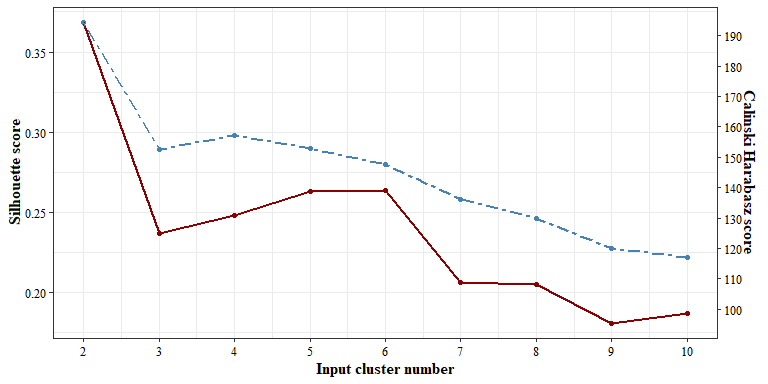

```r
scaleFactor <- max(index_df$silhouette_index) / max(index_df$Calinski_Harabasz)
k_index_plot <- ggplot(data = index_df, aes(x=Cluster))+
  geom_point(aes(y=silhouette_index), color = "darkred")+
  geom_point(aes(y=Calinski_Harabasz * scaleFactor), color = "steelblue")+
  geom_line(aes(y=silhouette_index), color = "darkred", size=1)+
  geom_line(aes(y=Calinski_Harabasz * scaleFactor), color = "steelblue", linetype="twodash", size=1)+
  scale_y_continuous(name="Silhouette score", breaks = seq(0, 0.4, 0.05),
                     sec.axis=sec_axis(~./scaleFactor,
                                       breaks=seq(100, 200, 10),
                                       name="Calinski Harabasz score"))+

  scale_x_continuous(name="Input cluster number", breaks = seq(2, 10, 1))+
  theme_bw()+
  theme(axis.title = element_text(face = "bold",color = "black",size = 12),
        axis.text = element_text(color = "black",size = 10),
        text = element_text(size = 8, color = "black", family="serif"))

k_index_plot
```

```r
if(!dir.exists("../../Result/figure/cluster/")){
  dir.create("../../Result/figure/cluster/", recursive = T)
}
#ggsave("../../Result/figure/cluster/best_K_cluster.pdf", k_index_plot, width = 8, height = 5, dpi = 600)
```

### Scatterplot and survival analysis per K clusters

- scatterplot
- survival analysis

```r
get_cluster <- function(knum=num){
  # knum=num
  cluster_plot <- list()
  for (i in 2:knum) {
    fit <- pam(feature_cln, k=i)
    #fit2 <- pamk(feature_cln, krange=i, criterion="asw")

    # data.frame(fit$pamobject$clustering) -> cluster1
    # data.frame(fit2$clustering) -> cluster2
    # cluster_res <- inner_join(cluster1 %>% setNames("Cluster_pamk") %>% rownames_to_column("SampleID"),
    #                           cluster2 %>% setNames("Cluster_pam") %>% rownames_to_column("SampleID"),
    #                           by ="SampleID") %>%
    #                mutate(Status = ifelse(Cluster_pamk == Cluster_pam, "Match", "Unmatch"))
    # table(cluster_res$Status)


    data.frame(fit$clustering) %>% rownames_to_column("SampleID") %>%
      setNames(c("SampleID", "Cluster")) %>%
      mutate(Cluster=paste0("S", Cluster),
             Cluster=factor(Cluster)) -> temp_cluster

    mdat_survival <- temp_cluster %>% inner_join(phen, by = c("SampleID"="Barcode"))
    mdat_feature <- temp_cluster %>% inner_join(feature_cln %>% rownames_to_column("SampleID"),
                                                by = "SampleID")

    # scatterplot
    scatter_pl <- fviz_cluster(fit, data = feature_cln,
                               geom = "point", ellipse = FALSE,
                               shape = 19, pointsize = 3,
                               main = paste0("K=",i),
                               ggtheme=theme_bw())+
      theme(plot.title = element_text(face = "bold",color = "black",size = 14, hjust = .5),
            axis.title = element_text(face = "bold",color = "black",size = 12),
            axis.text = element_text(color = "black",size = 10),
            text = element_text(size = 8, color = "black", family="serif"),
            panel.grid = element_blank(),
            legend.position = c(0.1, 0.1),
            legend.justification = c(0, 0),
            legend.key.height = unit(0.6, "cm"),
            legend.text = element_text(face = "bold", color = "black", size = 12))


    # survival analysis
    dat_sur <- mdat_survival %>% column_to_rownames("SampleID") %>%
      dplyr::select(Cluster, OS.Time, OS)
    cox <- coxph(Surv(OS.Time, OS) ~ Cluster, data = dat_sur)
    tmp <- summary(cox)
    tmp.wald <- data.frame(t(tmp$waldtest)) %>%
        setNames(c("Wald_test", "Wald_df", "Wald_pvlaue"))
    tmp.lg <- data.frame(t(tmp$logtest)) %>%
        setNames(c("lg_rank", "lg_rank_df", "lg_rank_pvlaue"))
    tmp.total <- cbind(tmp.wald, tmp.lg)

    pvalue <- paste(paste0("Log-Rank P=", signif(tmp.lg$lg_rank_pvlaue, 3)),
                  paste0("Cox P=", signif(tmp.wald$Wald_pvlaue, 3)), sep = "\n")
    factors <- levels(dat_sur$Cluster)
    surv_fit <- survfit(Surv(OS.Time, OS) ~ Cluster, data = dat_sur)
    info <- data.frame(time = surv_fit$time,
                  n.risk = surv_fit$n.risk,
                  n.event = surv_fit$n.event,
                  n.censor = surv_fit$n.censor,
                  surv = surv_fit$surv,
                  upper = surv_fit$upper,
                  lower = surv_fit$lower)

    sur_pl <- ggsurvplot(surv_fit,
             data = dat_sur,
             surv.median.line = "hv",
             add.all = TRUE,
             palette = "aaas",
             risk.table = TRUE,
             xlab = "Follow up time(Years)",
             legend = c(0.8, 0.2),
             legend.title = "",
             legend.labs = c("all", factors),
             break.x.by = 2,
             font.legend = c(10, "italic"),
             ggtheme = theme_bw())
    sur_pl$plot <- sur_pl$plot +
             annotate("text", x=3, y=0.2, label=pvalue)

    cbind_pl <- plot_grid(scatter_pl, sur_pl$plot, sur_pl$table,
                                   ncol = 1, align = "hv",
                                   rel_heights = c(4, 3, 1.5))
    name <- paste0("K", i)
    cluster_plot[[name]] <- cbind_pl
  }
  return(cluster_plot)
}
kcluster_plot_list <- get_cluster(knum = num)
```

- k=2 clusters

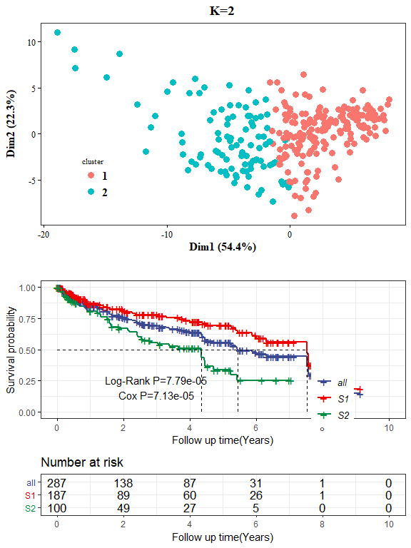

- k=3 clusters

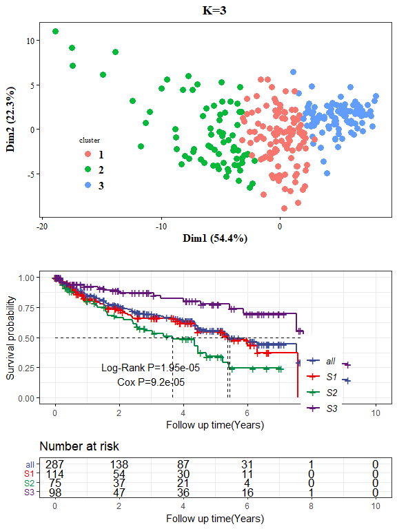

```r
kcluster_plot_list$K3
```

```r
ggsave("../../Result/figure/cluster/cluster_k3.pdf", kcluster_plot_list$K3, width = 6, height = 8, dpi = 600)
```

- k=4 clusters

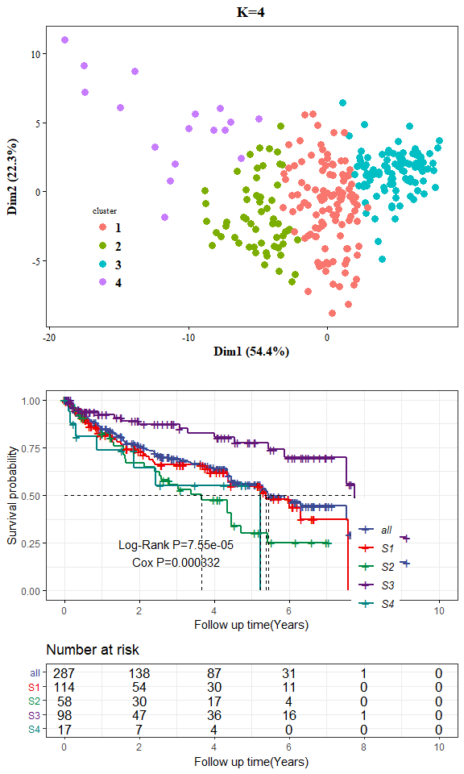

```r
kcluster_plot_list$K4
```

```r
ggsave("../../Result/figure/cluster/cluster_k4.pdf", kcluster_plot_list$K4, width = 6, height = 9, dpi = 600)
```

- k=5 clusters

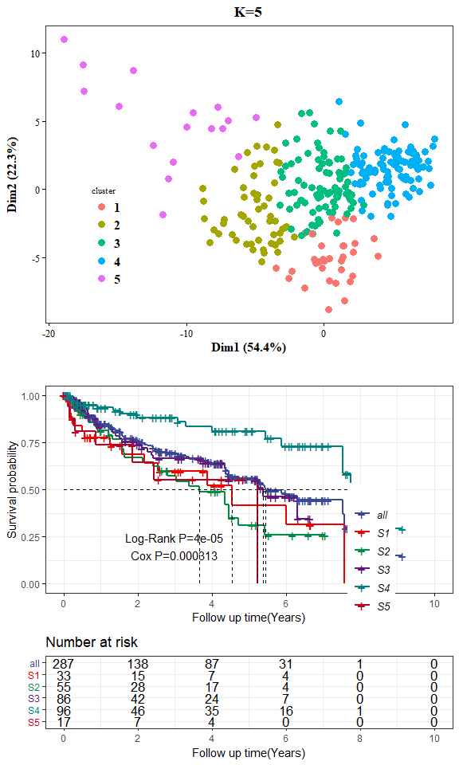

```r
kcluster_plot_list$K5
```

```r
ggsave("../../Result/figure/cluster/cluster_k5.pdf", kcluster_plot_list$K5, width = 6, height = 10, dpi = 600)
```

- k=6 clusters

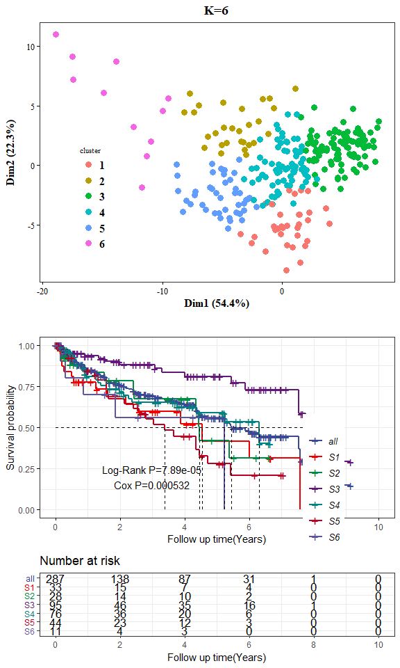

```r
kcluster_plot_list$K6
```

```r
ggsave("../../Result/figure/cluster/cluster_k6.pdf", kcluster_plot_list$K6, width = 6, height = 10, dpi = 600)
```

=====================================================================================================

### the final sub-clusters label

```r
phen_new <- inner_join(phen,
              data.frame(silhouette_index_fit$pamobject$clustering) %>%
               setNames("Cluster") %>%
               rownames_to_column("Barcode"),
             by = "Barcode") %>%
  dplyr::select(Barcode, Cluster, everything()) %>%
  mutate(Cluster=paste0("S", Cluster))

write.csv(phen_new, "../../Result/phenotype/phenotype_cluster.csv", row.names = F)

table(phen_new$Cluster)
```

```
 S1  S2
187 100
```

### Find the Optimal Number of Clusters

**kmeans(data, centers, nstart)**

*data*: Name of the dataset.

*centers*: The number of clusters, denoted k.

*nstart*: The number of initial configurations. Because it’s possible that different initial starting clusters can lead to different results, it’s recommended to use several different initial configurations. The k-means algorithm will find the initial configurations that lead to the smallest within-cluster variation.

- Number of Clusters vs. the Total Within Sum of Squares

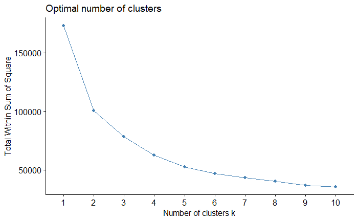

```r
fviz_nbclust(feature_cln, kmeans, method = "wss")
```

- Number of Clusters vs. Gap Statistic

```r
# calculate gap statistic based on number of clusters
gap_stat <- clusGap(feature_cln,
                    FUN = kmeans,
                    nstart = 25,
                    K.max = 10,
                    B = 50)
```

```
Clustering k = 1,2,..., K.max (= 10): .. done
Bootstrapping, b = 1,2,..., B (= 50)  [one "." per sample]:
.................................................. 50
```

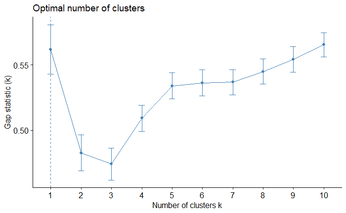

```r
# plot number of clusters vs. gap statistic
fviz_gap_stat(gap_stat)
```

- Perform K-Means Clustering with Optimal K

```r
# make this example reproducible
set.seed(123)

# perform k-means clustering with k = 4 clusters
km <- kmeans(feature_cln, centers = 2, nstart = 30)

# view results
km
```

[output not shown]

[output cut: 46 more lines]

```
TCGA_DV_5566 TCGA_DV_5567 TCGA_DV_5568 TCGA_DV_5569 TCGA_DV_5573 TCGA_DV_5574 TCGA_DV_5575 TCGA_DV_5576
           1            1            2            1            1            1            1            1
TCGA_DV_A4VX TCGA_DV_A4VZ TCGA_DV_A4W0 TCGA_EU_5904 TCGA_EU_5905 TCGA_EU_5906 TCGA_EU_5907 TCGA_G6_A5PC
           2            2            1            1            2            1            2            2
TCGA_G6_A8L6 TCGA_G6_A8L7 TCGA_G6_A8L8 TCGA_GK_A6C7 TCGA_MM_A563 TCGA_MM_A564 TCGA_MW_A4EC
           1            2            1            1            1            1            1

Within cluster sum of squares by cluster:
[1] 54217.64 46463.66
 (between_SS / total_SS =  41.8 %)

Available components:

[1] "cluster"      "centers"      "totss"        "withinss"     "tot.withinss" "betweenss"    "size"
[8] "iter"         "ifault"
```

```r
# compare the cluster result between kmeans and pamk
# data.frame(km$cluster) -> knn_cluster
# data.frame(Calinski_Harabasz_fit$pamobject$clustering) -> pamk_cluster
# cluster_res <- inner_join(knn_cluster %>% rownames_to_column("SampleID"), pamk_cluster %>% rownames_to_column("SampleID"), by ="SampleID") %>% setNames(c("SampleID", "knn", "pamk")) %>% mutate(Status = ifelse(knn == pamk, "Match", "Unmatch"))
# table(cluster_res$Status)
```

From the results we can see that:

- 196 states were assigned to the first cluster
- 91 states were assigned to the second cluster
- plot results of final k-means model

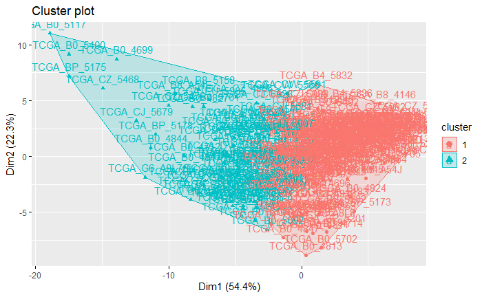

```r
fviz_cluster(km, data = feature_cln)
```

- find means of each cluster

```r
aggregate(feature_cln, by=list(cluster=km$cluster), mean)
```

| cluster | Feature100 | Feature001 | Feature009 | Feature067 | Feature014 | Feature070 | Feature098 | Feature057 | Feature059 | Feature090 | Feature016 | Feature002 | Feature019 | Feature088 | Feature066 | Feature017 | Feature071 | Feature075 | Feature036 | Feature007 | Feature015 | Feature028 | Feature052 | Feature093 | Feature054 | Feature022 | Feature072 | Feature086 | Feature058 | … |
| --- | --- | --- | --- | --- | --- | --- | --- | --- | --- | --- | --- | --- | --- | --- | --- | --- | --- | --- | --- | --- | --- | --- | --- | --- | --- | --- | --- | --- | --- | --- |
| 1 | 0.6764959 | 1.616574 | 0.2257455 | -3.048265 | -2.9958935 | 2.174671 | 2.8320554 | 3.180043 | -4.641815 | -0.5116551 | 2.1286484 | 0.7864945 | -1.630447 | -4.254774 | -5.9174024 | -6.141447 | 4.636569 | -0.5439231 | 2.674376 | 2.004541 | 1.506125 | 3.503804 | 4.543896 | -5.027537 | -4.252235 | 9.010091 | -4.8082109 | 0.3953138 | 3.801037 | … |
| 2 | 0.9757582 | -3.864110 | -4.1596681 | -7.205853 | 0.9353189 | 3.715629 | 0.2566911 | -2.023829 | 4.741165 | -5.8123212 | 0.7128023 | 0.2245218 | 2.342130 | -4.776252 | 0.1130268 | 2.782660 | 5.011389 | -5.0433883 | -7.300862 | -3.803186 | -1.724476 | 7.963796 | 5.259902 | 5.052492 | 5.047000 | 6.324112 | 0.4724298 | -5.6173771 | 5.678673 | … |

- We can also append the cluster assignments of each state back to the original dataset

```r
# add cluster assigment to original data
final_data <- cbind(cluster = km$cluster, feature_cln)

# view final data
head(final_data)
```

|  | cluster | Feature100 | Feature001 | Feature009 | Feature067 | Feature014 | Feature070 | Feature098 | Feature057 | Feature059 | Feature090 | Feature016 | Feature002 | Feature019 | Feature088 | Feature066 | Feature017 | Feature071 | Feature075 | Feature036 | Feature007 | Feature015 | Feature028 | Feature052 | Feature093 | Feature054 | Feature022 | Feature072 | Feature086 | … |
| --- | --- | --- | --- | --- | --- | --- | --- | --- | --- | --- | --- | --- | --- | --- | --- | --- | --- | --- | --- | --- | --- | --- | --- | --- | --- | --- | --- | --- | --- | --- |
| TCGA_3Z_A93Z | 1 | 1.77580595 | -2.30968904 | 0.8512433 | -4.5214186 | -1.565446 | 6.295428 | -1.517316 | 5.1338906 | -6.6051793 | 0.3664034 | 3.826818 | 0.56776476 | 1.1911680 | -4.59276152 | -4.683664 | -4.6621327 | 6.550019 | -3.018544 | 0.6654426 | 5.289061 | -1.7954798 | 4.188721 | 7.285595 | -9.596411 | -1.520979 | 9.722521 | -7.205501 | -0.4465639 | … |
| TCGA_6D_AA2E | 2 | -2.01074743 | -1.02999234 | -2.4656065 | -7.4665556 | -4.021830 | -1.378630 | 1.806100 | -2.7368331 | 3.3825729 | -7.4781046 | 4.383189 | -5.76769161 | -1.4760839 | -2.87563849 | -3.331406 | 0.2053692 | 6.620845 | -4.366866 | -8.6307364 | -2.380340 | -0.5424209 | 6.344688 | 8.611795 | 2.683972 | 3.739885 | 3.098587 | -2.589081 | -1.4329796 | … |
| TCGA_A3_3357 | 2 | -2.54984951 | -0.03711597 | -3.8331876 | -4.5785246 | -3.304933 | 0.281967 | 5.852617 | 0.1285527 | -0.9514673 | -1.4263098 | 4.159230 | -3.63323283 | -2.0558081 | -0.01712551 | -1.829850 | -2.3382397 | 4.904284 | -1.807552 | -3.1265240 | -4.204106 | -1.9031664 | 3.866973 | 6.810646 | 4.521963 | 1.332739 | 10.135919 | 2.284619 | -2.1749854 | … |
| TCGA_A3_3367 | 1 | 0.07807984 | 3.61161828 | -1.1944206 | -4.2043295 | -6.221794 | 1.157611 | 5.562993 | 2.4902542 | -5.5632119 | 0.7412874 | 2.674327 | -0.09861047 | -0.4485408 | -2.22755289 | -7.290384 | -6.0163116 | 4.269634 | -0.457354 | 2.3551173 | 1.425168 | 1.2774782 | 3.295835 | 5.733438 | -3.060523 | -2.960151 | 10.572782 | -1.275116 | -1.0831633 | … |
| TCGA_A3_3370 | 1 | 0.78047705 | 3.41607404 | 0.6068277 | -3.1363046 | -4.937724 | -0.412313 | 5.888155 | 4.7607203 | -6.2455444 | 1.4665083 | 1.930735 | -0.62254489 | -4.2953506 | -3.90106106 | -7.152658 | -8.7452660 | 1.770919 | 3.370201 | 4.4392853 | 1.441459 | 2.3037200 | 3.278285 | 3.975833 | -6.853994 | -8.464810 | 9.318328 | -4.120004 | 3.9363430 | … |
| TCGA_A3_3373 | 1 | -1.30066049 | 3.26502585 | 3.3397794 | 0.2591163 | -5.105055 | -1.664436 | 6.498281 | 5.9884043 | -6.9370565 | 2.7335658 | 4.492558 | 0.23470011 | -4.8094926 | -0.56799972 | -9.335258 | -11.7251043 | 3.561893 | 3.052567 | 5.4581332 | 1.472686 | 3.5231271 | 1.333800 | 4.191339 | -9.423734 | -8.197765 | 10.444356 | -5.713265 | 6.2252655 | … |

### Rtsne plot for K=2 clusters

```r
RtsneFun <- function(profile=feature,
                     metadata=phen_new,
                     perpl=50){

  # profile=feature
  # metadata=phen_new
  # perpl=50

  sid <- intersect(profile$SampleID, metadata$Barcode)

  pheno <- metadata %>% filter(Barcode%in%sid) %>%
    column_to_rownames("Barcode")
  edata <- profile %>% column_to_rownames("SampleID") %>%
    t() %>% data.frame() %>%
    dplyr::select(rownames(pheno))

  # determine the right order between profile and phenotype
  for(i in 1:ncol(edata)){
    if (!(colnames(edata)[i] == rownames(pheno)[i])) {
      stop(paste0(i, " Wrong"))
    }
  }

  # Rtsne
  require(Rtsne)
  #set.seed(123)
  Rtsne <- Rtsne(t(edata), dims=2, perplexity=perpl,
                verbose=TRUE, max_iter=500, eta=200)
  point <- Rtsne$Y %>% data.frame() %>%
    dplyr::select(c(1:2))%>%
    setnames(c("tSNE1", "tSNE2"))
  rownames(point) <- rownames(t(edata))
  # principal component score of each sample
  score <- inner_join(point %>% rownames_to_column("SampleID"),
                      pheno %>% rownames_to_column("SampleID"),
                      by = "SampleID") %>%
    mutate(Cluster=factor(Cluster, levels = grp))

  pl <- ggplot(score, aes(x=tSNE1, y=tSNE2))+
              geom_point(aes(color=Cluster), size=2)+
              guides(color=guide_legend(title=NULL,keywidth=.7, keyheight=.7))+
              scale_color_manual(values = grp.col)+
              theme_bw()+
              theme(axis.title = element_text(size=10, color="black", face="bold"),
                    axis.text = element_text(size=9, color="black"),
                    text = element_text(size=8, color="black", family="serif"),
                    strip.text = element_text(size=9, color="black", face="bold", family="serif"),
                    panel.grid = element_blank(),
                    legend.text=element_text(size=11, color = "black", family="serif"),
                    legend.position = c(0, 0),
                    legend.justification = c(0, 0),
                    legend.background = element_rect(color = "black", fill="white"))

  return(pl)
}

K2_rstne <- RtsneFun(profile=feature,metadata=phen_new,perpl=50)
```

```
Performing PCA
Read the 287 x 43 data matrix successfully!
OpenMP is working. 1 threads.
Using no_dims = 2, perplexity = 50.000000, and theta = 0.500000
Computing input similarities...
Building tree...
Done in 0.06 seconds (sparsity = 0.645316)!
Learning embedding...
Iteration 50: error is 49.554675 (50 iterations in 0.03 seconds)
Iteration 100: error is 48.559439 (50 iterations in 0.03 seconds)
Iteration 150: error is 48.570048 (50 iterations in 0.03 seconds)
Iteration 200: error is 48.522821 (50 iterations in 0.03 seconds)
Iteration 250: error is 48.569497 (50 iterations in 0.03 seconds)
Iteration 300: error is 0.343345 (50 iterations in 0.03 seconds)
Iteration 350: error is 0.340127 (50 iterations in 0.03 seconds)
Iteration 400: error is 0.339678 (50 iterations in 0.03 seconds)
Iteration 450: error is 0.339364 (50 iterations in 0.03 seconds)
Iteration 500: error is 0.338818 (50 iterations in 0.03 seconds)
Fitting performed in 0.28 seconds.
```

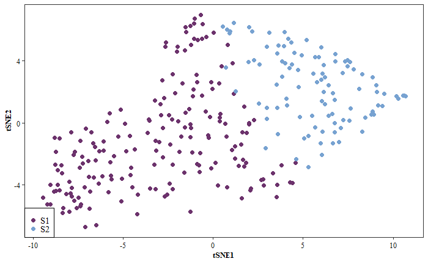

```r
K2_rstne
ggsave("../../Result/figure/cluster/cluster_k2_rstne.pdf", K2_rstne, width = 6, height = 5, dpi = 600)
```

### Pros & Cons of K-Means Clustering

K-means clustering offers the following benefits:

- It is a fast algorithm.
- It can handle large datasets well.

However, it comes with the following potential drawbacks:

- It requires us to specify the number of clusters before performing the algorithm.
- It’s sensitive to outliers.

### Reference

1. [K-Means Clustering in R: Step-by-Step Example](https://www.statology.org/k-means-clustering-in-r/#:~:text=%20K-Means%20Clustering%20in%20R%3A%20Step-by-Step%20Example%20,Clusters.%20Because%20it%E2%80%99s%20possible%20that%20different...%20More%20)
2. [Partitioning Around Medoids With Estimation Of Number Of Clusters](https://www.rdocumentation.org/packages/fpc/versions/2.2-5/topics/pamk)